# Indicators and Splines

MATH 456 Solutions

February 26, 2016

```r
library(ggplot2); library(car);library(knitr)
opts_chunk$set(warning=FALSE, message=FALSE, fig.height=5, fig.width=5, fig.align='center')
```

# Indicators

### Create a model to analyze the relationship of education status to depression level as measured by CESD after controlling for age.

**1. Ensure that you are using the analyzable version of the depression data set.**

```r
depress <- read.delim("C:/Github/MATH456/data/Depress_030816.txt")
```

**3. Ensure that R is treating “Up to HS” as the reference category for education level.**

```r
depress$EDUCAT2 <- recode(depress$EDUCAT, "'<HS' = 'Up to HS grad';
                                           'Some HS' = 'Up to HS grad';
                                           'HS Grad' = 'Up to HS grad'")
depress$EDUCAT2 <- factor(depress$EDUCAT2, levels=c("Up to HS grad", "Some college", "BS", "MS", "PhD"))
table(depress$EDUCAT2)
```

```
##
## Up to HS grad  Some college            BS            MS           PhD
##           180            48            43            14             9
```

The table reads left to right in increasing educational order. This provides confirmation that the recode and reordering was successful. The first level (Up to HS grad) will be treated as the reference group.

**4. Consider a transformation of `CESD`. Explain and justify using graphics.**

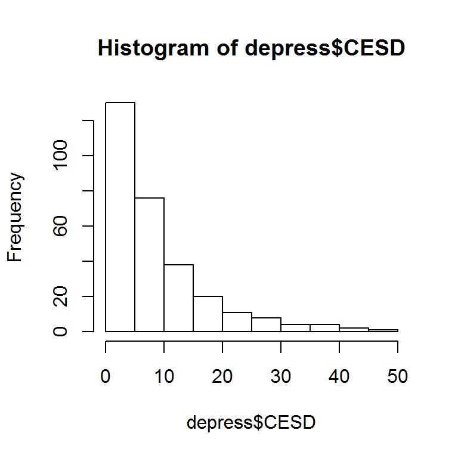

```r
hist(depress$CESD)
```

The value of CESD is skewed right. We can log-transform this variable, but since there are zero’s in the data, a small non-zero constant must be added prior to taking the log.

```r
min(depress$CESD[depress$CESD>0])
```

```
## [1] 1
```

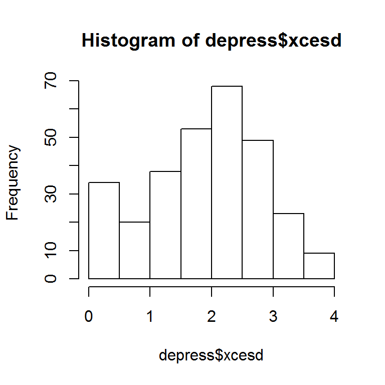

```r
depress$xcesd <- log(depress$CESD+1)
hist(depress$xcesd)
```

**5. Check the model fit by examining the residuals**

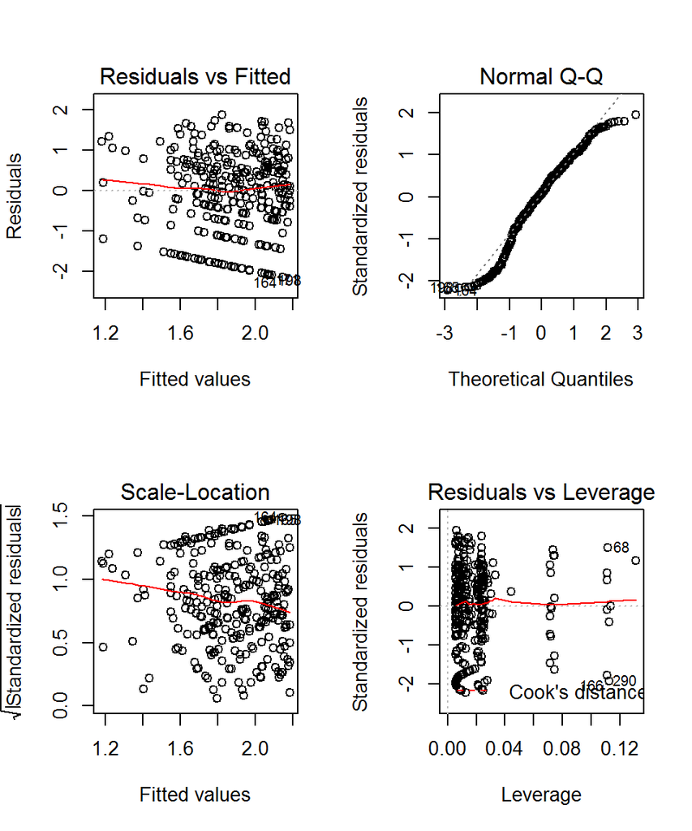

```r
par(mfrow=c(2,2))
model <- lm(xcesd ~ EDUCAT2 + AGE, data=depress)
plot(model)
```

*Residuals vs Fitted*: The residuals are not quite centered around zero, the trend line is slightly above the zero line at all times. There is a slight curve to this line which may indicate heteroscedasciticy, but this is not a gross violation.

*Normal Q-Q*: There appears to be some deviation away from the normal reference in the tails. This implies that the residuals perhaps follow a $t-$ distribution better than a standard normal $Z$ distribution.

**6. Identify any potential outliers.**  
The only points that R identifies with numbers really do not stick out from the rest of the data points. *Residuals vs. Leverage*: The leverage cutoff value is `4/NROW(depress)` = 0.014, which would cutoff nearly half of the data points being used. This is not a useful nor helpful finding.

This model does not have the best fit, which means the predictor variables used are likely not correct or optimal variables to use to predict depression score.

**7. Interpret ALL coefficients in context of the problem.**

```r
summary(model)
```

```
##
## Call:
## lm(formula = xcesd ~ EDUCAT2 + AGE, data = depress)
##
## Residuals:
##      Min       1Q   Median       3Q      Max
## -2.14764 -0.54407  0.07653  0.70946  1.88891
##
## Coefficients:
##                      Estimate Std. Error t value Pr(>|t|)
## (Intercept)          2.362961   0.169437  13.946  < 2e-16 ***
## EDUCAT2Some college -0.100894   0.159822  -0.631  0.52835
## EDUCAT2BS            0.017762   0.167967   0.106  0.91586
## EDUCAT2MS           -0.598218   0.269520  -2.220  0.02723 *
## EDUCAT2PhD          -0.254887   0.331321  -0.769  0.44234
## AGE                 -0.009787   0.003224  -3.036  0.00262 **
## ---
## Signif. codes:  0 '***' 0.001 '**' 0.01 '*' 0.05 '.' 0.1 ' ' 1
##
## Residual standard error: 0.97 on 288 degrees of freedom
## Multiple R-squared:  0.04917,    Adjusted R-squared:  0.03267
## F-statistic: 2.979 on 5 and 288 DF,  p-value: 0.01223
```

```r
round(expm1(model$coefficients)*c(1,rep(100,5)),2)
```

```
##         (Intercept) EDUCAT2Some college           EDUCAT2BS
##                9.62               -9.60                1.79
##           EDUCAT2MS          EDUCAT2PhD                 AGE
##              -45.02              -22.50               -0.97
```

- The baseline level of depression for someone who has not gone to college and is zero years old is 9.6.
- For every year older a person is, the depression score significantly decreases by about 1% (p=.003)
- Those with some college have 9.6% lower depression score compared to those with no college experience. This difference is not significant.
- Those with a BS degree have a 1.8% higher depression score compared to those with no college experience. This difference is not significant.
- Those with a MS degree have a 45% lower depression score compared to those with up to a HS degree (p=.02).
- Those with a PhD have a 22% lower depression score compared to those with up to a HS degree. This difference is not significant.

*Take home message: go to grad school!*

To test that education level as a whole does not significantly affect a persons depression score I conduct an F test for $\beta_{some college} = \beta_{BS} = \beta_{MS} =\beta_{PhD}=0$.

```r
anova(model, lm(xcesd ~ AGE, data=depress))
```

```
## Analysis of Variance Table
##
## Model 1: xcesd ~ EDUCAT2 + AGE
## Model 2: xcesd ~ AGE
##   Res.Df    RSS Df Sum of Sq      F Pr(>F)
## 1    288 270.95
## 2    292 276.30 -4   -5.3497 1.4216 0.2268
```

The addition of education to the model of depression score does not significantly reduce the residual sums of squares (a.k.a. SSE). This indicates that education does not add information to predict or explain the depression score. Hence we would fail to reject the null hypothesis that education does not affect depression level.

**8. Does this model do well at all in predicting CESD?** This model explains less than 5% of the variation in the log of CESD (adjusted $R^{2}$ = .03). The test for overall model fit is significant at the 5% level however (p=.01), which indicates that this model (while not good) does better to predict CESD than just using the average CESD value. This is likely due to the addition of age in the model. So while Education level does not contribute to the understanding of CESD, age does.

# Splines

**1. Using the `cars` data set built into R, build a model to predict the distance a car takes to stop based on how fast it was going.**

Visualize the relationship between speed and distance.

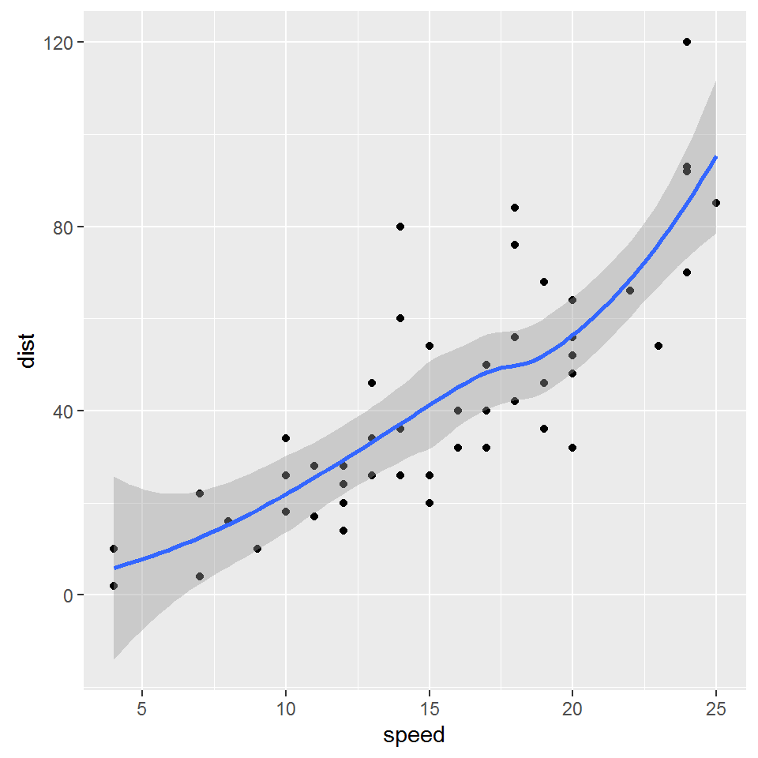

```r
ggplot(cars, aes(x=speed, y=dist)) + geom_point() + geom_smooth()
```

First glance doesn’t look too non-linear, so let’s create a simple linear regression model.

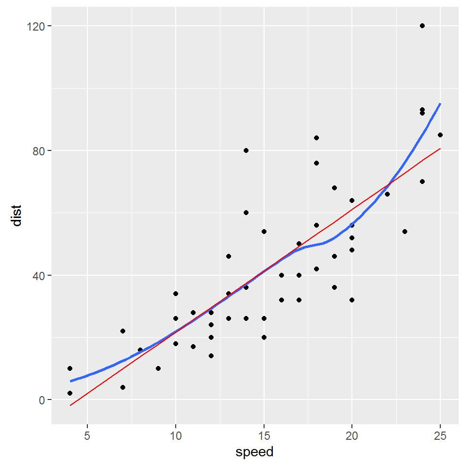

```r
slr <- lm(dist~speed, data=cars)
ggplot(cars, aes(x=speed, y=dist)) + geom_point() + geom_smooth(se=FALSE) +
  geom_line(aes(y=predict(slr)), col="red")
```

There doesn’t appear to be a very strong curvature, so I don’t think a squared or cubic term is needed but let’s confirm.

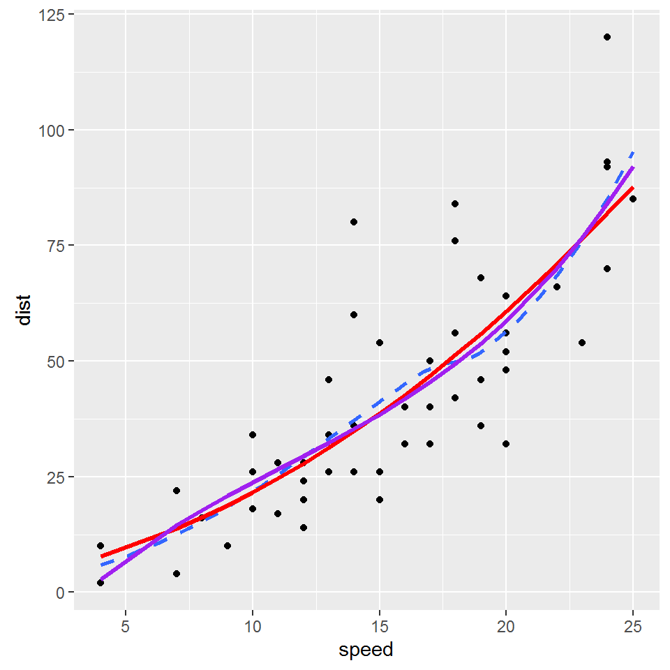

```r
sp2 <- cars$speed^2
sp3 <- cars$speed^3

fit.sq <- lm(cars$dist ~ cars$speed + sp2)
fit.cub <- lm(cars$dist ~ cars$speed + sp2 + sp3)

ggplot(cars, aes(x=speed, y=dist)) +
      geom_point() + geom_smooth(se=FALSE, lty=2) +
      geom_line(aes(x=speed, y=predict(fit.sq)), col="red", lwd=1.2) +
      geom_line(aes(x=speed, y=predict(fit.cub)), col="purple", lwd=1.2)
```

A cubic definitely over fits the data, the squared term may be ok. Let’s revisit the linear model and put a few knots where it seems to deviate away from the lowess line.

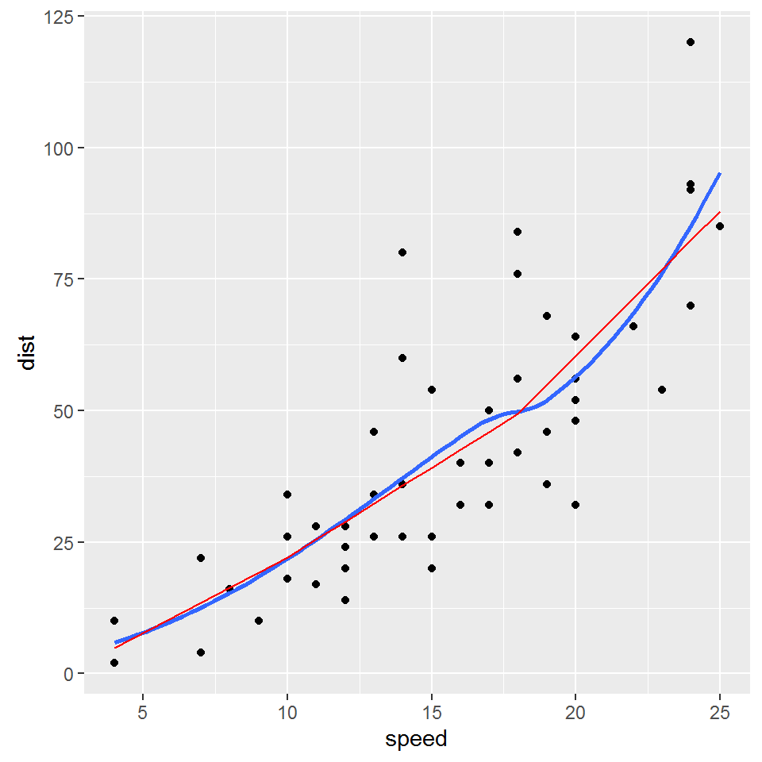

```r
x10 <- (cars$speed-10)
x10[ x10<0 ] <- 0

x18 <- (cars$speed-18)
x18[ x18<0 ] <- 0

fit.lin.spline <- lm(cars$dist ~ cars$speed + x10 + x18)

ggplot(cars, aes(x=speed, y=dist)) +
    geom_point() + geom_smooth(se=FALSE) +
    geom_line(aes(x=speed, y=predict(fit.lin.spline)), col="red")
```

Perhaps a little better. There is still a wiggle around 18 mph, so last attempt will be a natural spline with a polynomial of rank 3.

```r
library(splines)
fit.ns <- lm(cars$dist ~ ns(cars$speed,3))

summary(fit.ns)
```

```
##
## Call:
## lm(formula = cars$dist ~ ns(cars$speed, 3))
##
## Residuals:
##     Min      1Q  Median      3Q     Max
## -26.789  -9.750  -2.421   7.326  44.203
##
## Coefficients:
##                    Estimate Std. Error t value Pr(>|t|)
## (Intercept)           2.594      9.057   0.286 0.775875
## ns(cars$speed, 3)1   35.959      8.731   4.118 0.000157 ***
## ns(cars$speed, 3)2   96.444     20.561   4.691 2.46e-05 ***
## ns(cars$speed, 3)3   72.986      8.021   9.099 7.49e-12 ***
## ---
## Signif. codes:  0 '***' 0.001 '**' 0.01 '*' 0.05 '.' 0.1 ' ' 1
##
## Residual standard error: 15.23 on 46 degrees of freedom
## Multiple R-squared:  0.6722, Adjusted R-squared:  0.6508
## F-statistic: 31.44 on 3 and 46 DF,  p-value: 3.298e-11
```

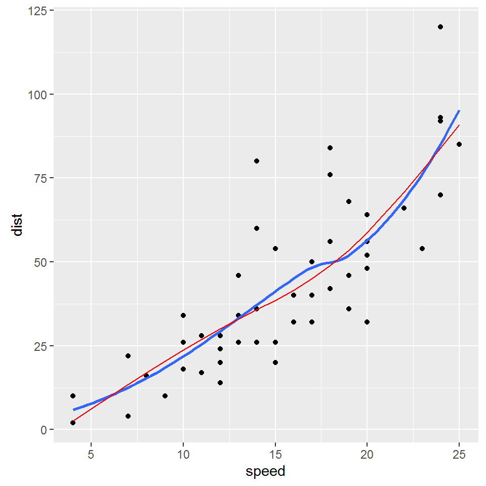

```r
ggplot(cars, aes(x=speed, y=dist)) +
    geom_point() + geom_smooth(se=FALSE) +
    geom_line(aes(x=speed, y=predict(fit.ns)), col="red")
```

At this point my candidate models are the linear spline with 2 knots and the quadratic model. I will compare the models on $R^{2}$ and RMSE.

```r
summary(fit.lin.spline)$adj.r.squared
```

```
## [1] 0.6441308
```

```r
summary(fit.sq)$adj.r.squared
```

```
## [1] 0.6531747
```

```r
summary(fit.lin.spline)$sigma
```

```
## [1] 15.37266
```

```r
summary(fit.sq)$sigma
```

```
## [1] 15.17607
```

The model with speed squared has a larger adjusted $R^{2}$ value and a lower RMSE value. However this difference is so slight that I will conclude that these models perform equally well.

2. Using the family lung function data, build a model to predict FEV1 to height for the oldest child.

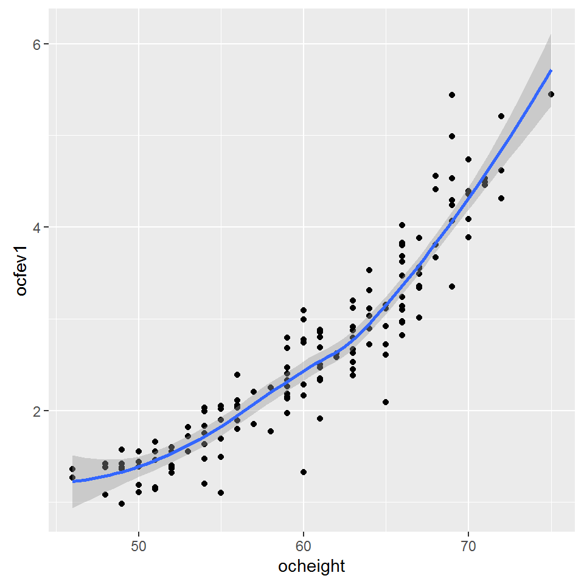

```r
fev <- read.table("C:/Github/MATH456/data/Lung_020716.txt", sep="\t", header=TRUE)
names(fev) <- tolower(names(fev))
qplot(x=ocheight, y=ocfev1, data=fev, geom='point') + geom_smooth()
```

**SLR**

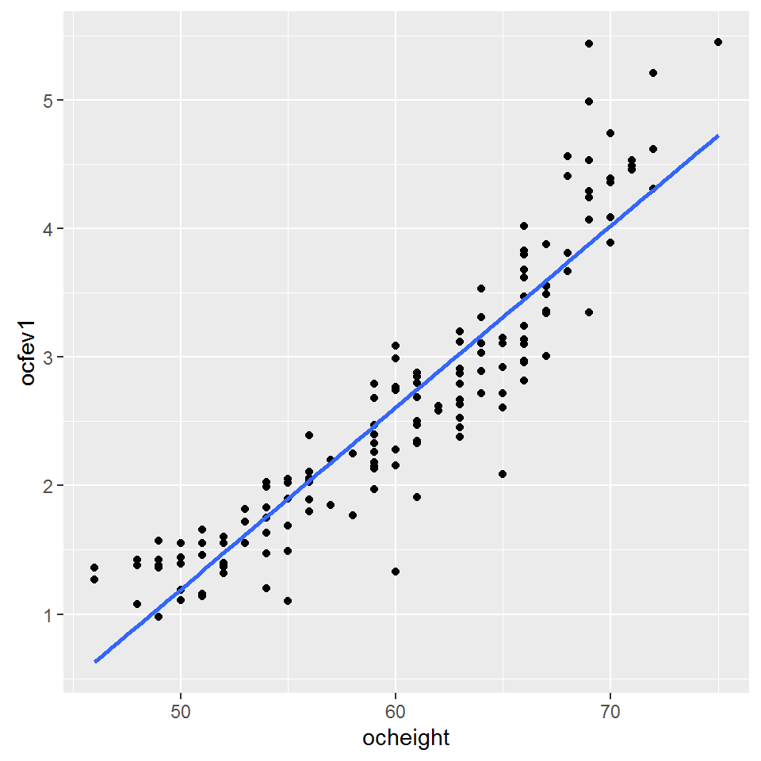

```r
slr <- lm(ocfev1 ~ ocheight, data=fev)
ggplot(fev, aes(x=ocheight, y=ocfev1)) + geom_point() + geom_smooth(se=FALSE, method="lm")
```

**Polynomial**

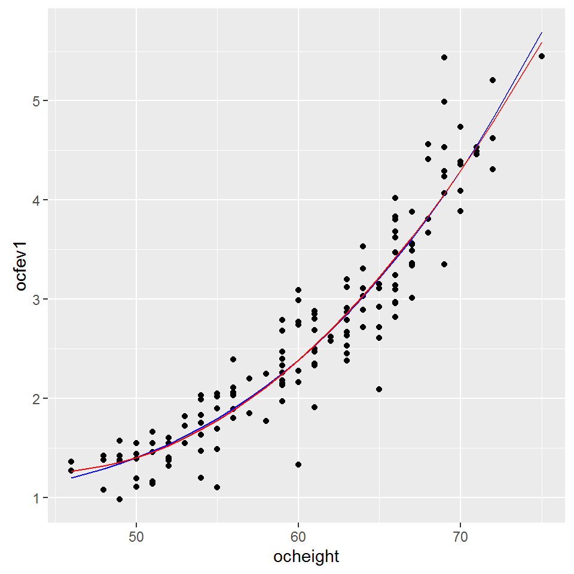

```r
fev$ocheight.sq <- fev$ocheight^2
sqr.model <- lm(ocfev1 ~ ocheight + ocheight.sq, data=fev)

fev$ocheight.cub <- fev$ocheight^3
cub.model <- lm(ocfev1 ~ ocheight + ocheight.sq + ocheight.cub, data=fev)

# Plot both on same graph
ggplot(fev, aes(x=ocheight, y=ocfev1)) + geom_point() +
  geom_line(aes(x=ocheight, y=predict(cub.model)), col="blue") +
  geom_line(aes(x=ocheight, y=predict(sqr.model)), col="red")
```

**Linear Splines** *Note: A knots at 55 and 64 are just used as demonstration purposes. You need to justify your knot placement*

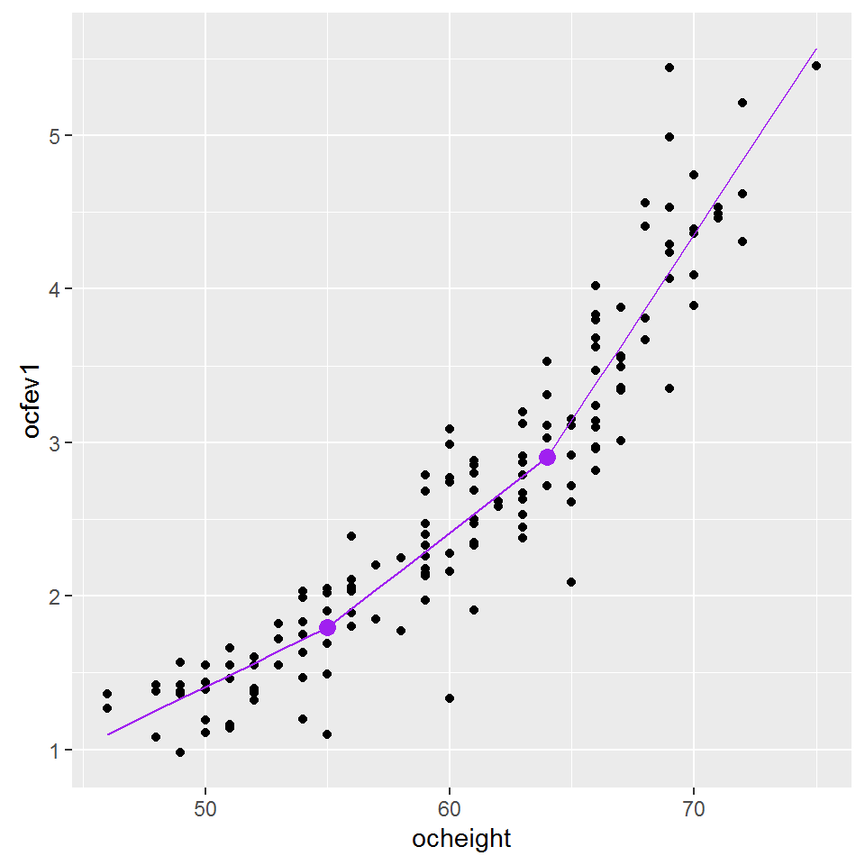

```r
# create the knot
gt55 <- (fev$ocheight-55)
gt55[ gt55<0 ] <- 0
gt64 <- (fev$ocheight-64)
gt64[ gt64<0 ] <- 0

# Run the model
lin_spl  <- lm(ocfev1 ~ ocheight + gt55 + gt64, data=fev)

# calculate predictions for the points at knots for plotting
new.dta <- data.frame(ocheight=c(55, 64), gt55=c(0,9), gt64=c(0,0))
pred.pts <- predict(lin_spl, new.dta)

# plot the data and model prediction
ggplot(fev, aes(x=ocheight, y=ocfev1)) + geom_point() +
    geom_point(x=55, y=pred.pts[1], size=3, col="purple") +
    geom_point(x=64, y=pred.pts[2], size=3, col="purple") +
    geom_line(aes(x=ocheight, y=predict(lin_spl)), col="purple")
```

Hint: Look at `model.matrix(lm(ocfev1 ~ ocheight + gt55 + gt64, data=fev))` to see why the x-values for gt55 is 9 when ocheight is 64.

**Cubic splines**

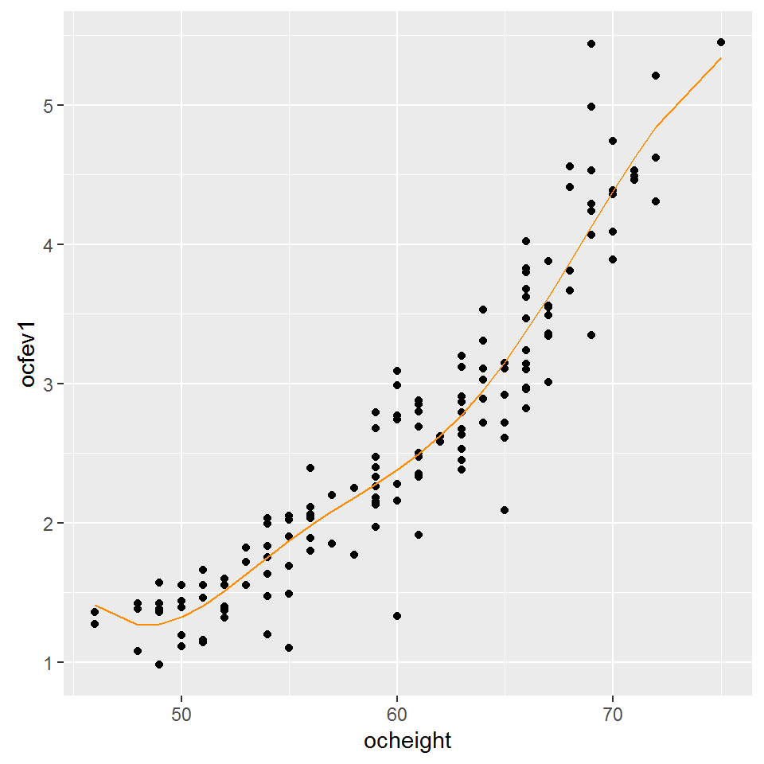

```r
gt55.3 <- gt55^3
gt64.3 <- gt64^3

cub.spline <- lm(ocfev1 ~ ocheight + ocheight.sq + ocheight.cub + gt55.3 + gt64.3, data=fev)

ggplot(fev, aes(x=ocheight, y=ocfev1)) + geom_point() +
    geom_line(aes(x=ocheight, y=predict(cub.spline)), col="darkorange")
```

**Natural splines**

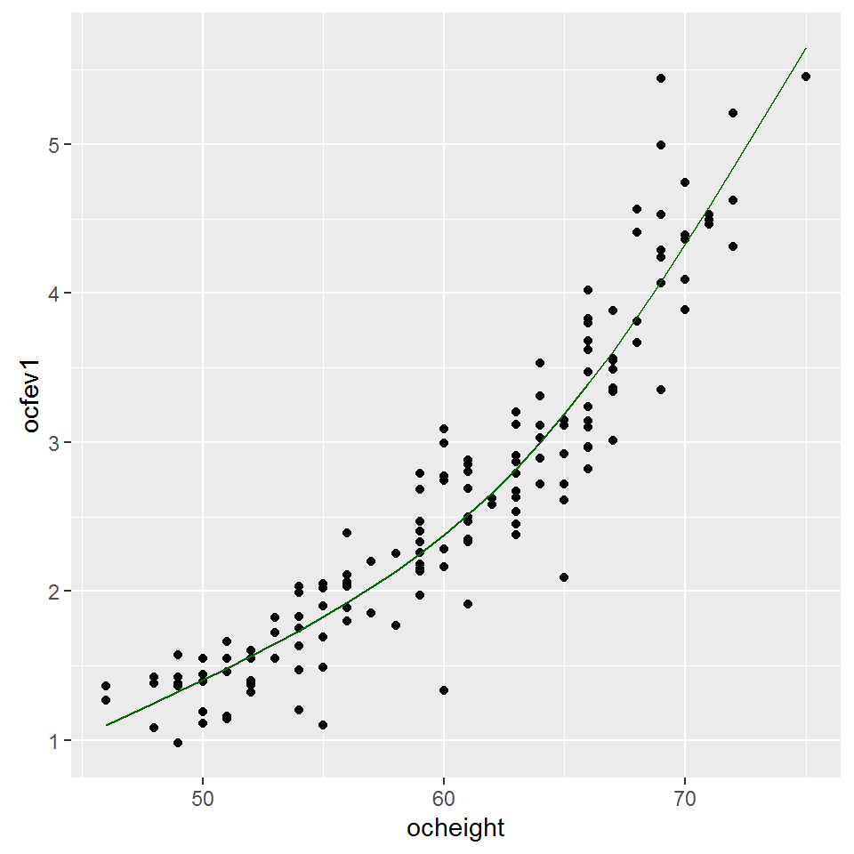

```r
library(splines)
fit.ns <- lm(ocfev1 ~ ns(ocheight, 3), data=fev )
ggplot(fev, aes(x=ocheight, y=ocfev1)) + geom_point() +
    geom_line(aes(x=ocheight, y=predict(fit.ns)), col="darkgreen")
```

```r
out <- cbind(
R.sq = c(summary(sqr.model)$adj.r.squared,
                   summary(cub.model)$adj.r.squared,
                   summary(lin_spl)$adj.r.squared,
                   summary(fit.ns)$adj.r.squared),
RMSE = c(summary(sqr.model)$sigma,
          summary(cub.model)$sigma,
          summary(lin_spl)$sigma,
          summary(fit.ns)$sigma)
)
rownames(out) <- c("squared", "cubic", "linear spline", "natural spline")
kable(out, digits=4)
```

|  | R.sq | RMSE |
| --- | --- | --- |
| squared | 0.8935 | 0.3464 |
| cubic | 0.8930 | 0.3471 |
| linear spline | 0.8961 | 0.3420 |
| natural spline | 0.8938 | 0.3458 |

All models perform equivalently. The linear spline has the highest R squared and lowest RMSE, and is easiest to interpret.